# Project: Investigate a Dataset (TMDb movie data)

- Introduction
- Data Wrangling
- Exploratory Data Analysis
- Conclusions

## Introduction

The Movie Database (TMDb) is a community built movie and TV database.  
In this presentation, based on this dataset various questions will be answered for the curious minds. The TMDb movie data set cleaned from original data on Kaggle is investigated to answer some questions.

#### Questions

- Which genres are most popular from year to year?
- How much the movie genres change from year to year?
- How many movies based on their genres were produced?
- Which are some of the top movies based on features like adjusted revenue and budget, popularity.
- Have revenues increased over time?
- Do higher revenue films make more profits?

```python
# All imports here
import pandas as pd
import numpy as np
import seaborn as sns
import operator
from datetime import datetime
import matplotlib.pyplot as pt
%matplotlib inline
```

## Data Wrangling

### General Properties

```python
# Load the data and print out a few lines
df = pd.read_csv("tmdb-movies.csv")
df.head()
```

|  | id | imdb_id | popularity | budget | revenue | original_title | cast | homepage | director | tagline | ... | overview | runtime | genres | production_companies | release_date | vote_count | vote_average | release_year | budget_adj | revenue_adj |
| --- | --- | --- | --- | --- | --- | --- | --- | --- | --- | --- | --- | --- | --- | --- | --- | --- | --- | --- | --- | --- | --- |
| 0 | 135397 | tt0369610 | 32.985763 | 150000000 | 1513528810 | Jurassic World | Chris Pratt\|Bryce Dallas Howard\|Irrfan Khan\|Vi... | http://www.jurassicworld.com/ | Colin Trevorrow | The park is open. | ... | Twenty-two years after the events of Jurassic ... | 124 | Action\|Adventure\|Science Fiction\|Thriller | Universal Studios\|Amblin Entertainment\|Legenda... | 6/9/15 | 5562 | 6.5 | 2015 | 1.379999e+08 | 1.392446e+09 |
| 1 | 76341 | tt1392190 | 28.419936 | 150000000 | 378436354 | Mad Max: Fury Road | Tom Hardy\|Charlize Theron\|Hugh Keays-Byrne\|Nic... | http://www.madmaxmovie.com/ | George Miller | What a Lovely Day. | ... | An apocalyptic story set in the furthest reach... | 120 | Action\|Adventure\|Science Fiction\|Thriller | Village Roadshow Pictures\|Kennedy Miller Produ... | 5/13/15 | 6185 | 7.1 | 2015 | 1.379999e+08 | 3.481613e+08 |
| 2 | 262500 | tt2908446 | 13.112507 | 110000000 | 295238201 | Insurgent | Shailene Woodley\|Theo James\|Kate Winslet\|Ansel... | http://www.thedivergentseries.movie/#insurgent | Robert Schwentke | One Choice Can Destroy You | ... | Beatrice Prior must confront her inner demons ... | 119 | Adventure\|Science Fiction\|Thriller | Summit Entertainment\|Mandeville Films\|Red Wago... | 3/18/15 | 2480 | 6.3 | 2015 | 1.012000e+08 | 2.716190e+08 |
| 3 | 140607 | tt2488496 | 11.173104 | 200000000 | 2068178225 | Star Wars: The Force Awakens | Harrison Ford\|Mark Hamill\|Carrie Fisher\|Adam D... | http://www.starwars.com/films/star-wars-episod... | J.J. Abrams | Every generation has a story. | ... | Thirty years after defeating the Galactic Empi... | 136 | Action\|Adventure\|Science Fiction\|Fantasy | Lucasfilm\|Truenorth Productions\|Bad Robot | 12/15/15 | 5292 | 7.5 | 2015 | 1.839999e+08 | 1.902723e+09 |
| 4 | 168259 | tt2820852 | 9.335014 | 190000000 | 1506249360 | Furious 7 | Vin Diesel\|Paul Walker\|Jason Statham\|Michelle ... | http://www.furious7.com/ | James Wan | Vengeance Hits Home | ... | Deckard Shaw seeks revenge against Dominic Tor... | 137 | Action\|Crime\|Thriller | Universal Pictures\|Original Film\|Media Rights ... | 4/1/15 | 2947 | 7.3 | 2015 | 1.747999e+08 | 1.385749e+09 |

5 rows × 21 columns

```python
# Check the datatypes of all the columns
df.dtypes
```

```
id                        int64
imdb_id                  object
popularity              float64
budget                    int64
revenue                   int64
original_title           object
cast                     object
homepage                 object
director                 object
tagline                  object
keywords                 object
overview                 object
runtime                   int64
genres                   object
production_companies     object
release_date             object
vote_count                int64
vote_average            float64
release_year              int64
budget_adj              float64
revenue_adj             float64
dtype: object
```

### Observations

1. Unit of currency is not mentioned in the dataset. We would take USD as it is the most common *de facto global currency*.
2. vote_count is different for different movies, so the popularity of the movies can't be concluded based on the vote_average.

## Data Cleaning

### Removing unnecessary columns

> 'imdb_id', 'homepage', 'keywords', 'overview', 'production_companies', 'vote_count', 'vote_average'

```python
# List of columns to be deleted
del_col = ['imdb_id', 'homepage', 'keywords', 'overview', 'production_companies', 'vote_count', 'vote_average']
```

```python
# Delete the columns
df = df.drop(del_col, 1)

# Updated dataset
df.head(1)
```

|  | id | popularity | budget | revenue | original_title | cast | director | tagline | runtime | genres | release_date | release_year | budget_adj | revenue_adj |
| --- | --- | --- | --- | --- | --- | --- | --- | --- | --- | --- | --- | --- | --- | --- |
| 0 | 135397 | 32.985763 | 150000000 | 1513528810 | Jurassic World | Chris Pratt\|Bryce Dallas Howard\|Irrfan Khan\|Vi... | Colin Trevorrow | The park is open. | 124 | Action\|Adventure\|Science Fiction\|Thriller | 6/9/15 | 2015 | 1.379999e+08 | 1.392446e+09 |

### Removing duplicate rows

```python
# Check for existence of duplicate rows
df.duplicated(subset=None, keep='first').sum()
```

```
1
```

```python
# Print the duplicate row
duplicated_row = df[df.duplicated(subset=None, keep='first') == True]
duplicated_row
```

|  | id | popularity | budget | revenue | original_title | cast | director | tagline | runtime | genres | release_date | release_year | budget_adj | revenue_adj |
| --- | --- | --- | --- | --- | --- | --- | --- | --- | --- | --- | --- | --- | --- | --- |
| 2090 | 42194 | 0.59643 | 30000000 | 967000 | TEKKEN | Jon Foo\|Kelly Overton\|Cary-Hiroyuki Tagawa\|Ian... | Dwight H. Little | Survival is no game | 92 | Crime\|Drama\|Action\|Thriller\|Science Fiction | 3/20/10 | 2010 | 30000000.0 | 967000.0 |

> It is observed that there exists a duplicated row. So it has to be removed.

```python
# Check the original dataset's shape
df.shape
```

```
(10866, 14)
```

```python
# Remove the duplicated row
df.drop_duplicates(keep ='first', inplace=True)

# Check the new shape of the dataset
df.shape
```

```
(10865, 14)
```

### Removing 0's from budget and the revenue columns

```python
# Replace all 0's with NAN
df[['budget', 'revenue']] = df[['budget', 'revenue']].replace(0, np.NAN)
```

```python
# Count rows with budget or revenue as NAN
df[['budget', 'revenue']].isna().sum()
```

```
budget     5696
revenue    6016
dtype: int64
```

```python
# Remove these rows
df.dropna(subset = ['budget', 'revenue'], inplace = True)

# Check the new shape of the dataset
df.shape
```

```
(3854, 14)
```

### Removing NaN values from cast column

```python
# Check for NaN in cast column
df[df["cast"].isnull() == True]
```

|  | id | popularity | budget | revenue | original_title | cast | director | tagline | runtime | genres | release_date | release_year | budget_adj | revenue_adj |
| --- | --- | --- | --- | --- | --- | --- | --- | --- | --- | --- | --- | --- | --- | --- |
| 4127 | 21925 | 0.193929 | 3000000.0 | 13308.0 | Naqoyqatsi | NaN | Godfrey Reggio | America is test-driving the future | 89 | Documentary\|Drama\|Music\|Thriller | 9/2/02 | 2002 | 3.636784e+06 | 1.613277e+04 |
| 4889 | 126509 | 0.075043 | 2500000.0 | 33400000.0 | 2016: Obama's America | NaN | Dinesh D'Souza\|John Sullivan | Love Him, Hate Him, You Don't Know Him | 87 | Documentary | 7/13/12 | 2012 | 2.374361e+06 | 3.172146e+07 |
| 7813 | 22887 | 0.065543 | 6000.0 | 6000.0 | Loose Change: Final Cut | NaN | Dylan Avery | NaN | 129 | Documentary | 11/11/07 | 2007 | 6.310011e+03 | 6.310011e+03 |
| 9564 | 24348 | 0.168545 | 2500000.0 | 589244.0 | Powaqqatsi | NaN | Godfrey Reggio | NaN | 99 | Documentary\|Drama\|Music | 4/29/88 | 1988 | 4.609728e+06 | 1.086502e+06 |

```python
# Remove those rows
df = df[df["cast"].isnull() == False]
```

### Changing the release date column into standard date format

```python
# Change the date format
df.release_date = pd.to_datetime(df.release_date)
```

```python
# Check the new data type of release_date column
type(df.release_date[0])
```

```
pandas._libs.tslibs.timestamps.Timestamp
```

### Changing format of budget and revenue column

```python
# Print the data types of the columns
df.dtypes
```

```
id                         int64
popularity               float64
budget                   float64
revenue                  float64
original_title            object
cast                      object
director                  object
tagline                   object
runtime                    int64
genres                    object
release_date      datetime64[ns]
release_year               int64
budget_adj               float64
revenue_adj              float64
dtype: object
```

```python
# Change data type of budget and revenue columns to int
df[['budget', 'revenue']] = df[['budget', 'revenue']].applymap(np.int64)

# Print the data types of columns after the change
print(type(df.budget[0]))
print(type(df.revenue[0]))
```

```
<class 'numpy.int64'>
<class 'numpy.int64'>
```

### Rename budget and revenue columns to include currency

```python
# Rename the budget and revenue columns
df.rename(columns = {'budget': 'budget(in_USD)', 'revenue': 'revenue(in_USD)'}, inplace = True)

# Check the changed column names
df.head(0)
```

|  | id | popularity | budget(in_USD) | revenue(in_USD) | original_title | cast | director | tagline | runtime | genres | release_date | release_year | budget_adj | revenue_adj |
| --- | --- | --- | --- | --- | --- | --- | --- | --- | --- | --- | --- | --- | --- | --- |

## Exploratory Data Analysis

### Research Question 1: Which genres are most popular from year to year?

```python
#Create empty sets to hold unique release years and genres separately
year_set = set()
genre_set = set()
```

```python
# Create a new dataframe containing only the genres and release years
genres_and_year = df[["genres", "release_year"]]
genres_and_year.head()
```

|  | genres | release_year |
| --- | --- | --- |
| 0 | Action\|Adventure\|Science Fiction\|Thriller | 2015 |
| 1 | Action\|Adventure\|Science Fiction\|Thriller | 2015 |
| 2 | Adventure\|Science Fiction\|Thriller | 2015 |
| 3 | Action\|Adventure\|Science Fiction\|Fantasy | 2015 |
| 4 | Action\|Crime\|Thriller | 2015 |

```python
# Create a set of unique years of movies
production_year = genres_and_year["release_year"]
production_year = production_year.drop_duplicates()
for year in production_year:
    if year not in year_set:
        year_set.add(year)

print(year_set)
```

```
{1960, 1961, 1962, 1963, 1964, 1965, 1966, 1967, 1968, 1969, 1970, 1971, 1972, 1973, 1974, 1975, 1976, 1977, 1978, 1979, 1980, 1981, 1982, 1983, 1984, 1985, 1986, 1987, 1988, 1989, 1990, 1991, 1992, 1993, 1994, 1995, 1996, 1997, 1998, 1999, 2000, 2001, 2002, 2003, 2004, 2005, 2006, 2007, 2008, 2009,…
```

```python
# Create a set of unique genres by parsing all the years
for year in year_set:
    genres_in_year = genres_and_year[genres_and_year.release_year == year]
    genres_in_year = genres_in_year["genres"].values
    #print(genres_in_year)
    for elem in genres_in_year:
        genres_row = elem.split("|")
        #print(genres_row)
        for genre in genres_row:
            if genre not in genre_set:
                genre_set.add(genre)

print(genre_set)
```

```
{'Documentary', 'Western', 'Horror', 'Romance', 'Family', 'Thriller', 'Animation', 'Comedy', 'Adventure', 'Music', 'Crime', 'TV Movie', 'Mystery', 'Fantasy', 'Science Fiction', 'History', 'War', 'Foreign', 'Action', 'Drama'}
```

```python
# Create a dataframe which contains the sum of movies genre per year
genre_count_per_year = pd.DataFrame(index = year_set, columns=genre_set)
genre_count_per_year[:] = 0

for year in year_set:
    genre_dict = {}
    genres_in_year = genres_and_year[genres_and_year.release_year == year]
    genres_in_year = genres_in_year["genres"].values
    for elem in genres_in_year:
        genres_row = elem.split("|")
        for genre in genres_row:
            if genre not in genre_dict:
                genre_dict[genre] = 1
            else:
                genre_dict[genre] = genre_dict[genre] + 1

    aux_df = pd.DataFrame(genre_dict, index = [year])
    genre_count_per_year.loc[year, aux_df.columns] = genre_count_per_year.loc[year, aux_df.columns] + aux_df.loc[year]

genre_count_per_year.head()
```

|  | Documentary | Western | Horror | Romance | Family | Thriller | Animation | Comedy | Adventure | Music | Crime | TV Movie | Mystery | Fantasy | Science Fiction | History | War | Foreign | Action | Drama |
| --- | --- | --- | --- | --- | --- | --- | --- | --- | --- | --- | --- | --- | --- | --- | --- | --- | --- | --- | --- | --- |
| 1960 | 0 | 1 | 1 | 2 | 0 | 1 | 0 | 2 | 1 | 0 | 0 | 0 | 0 | 0 | 0 | 1 | 0 | 0 | 2 | 3 |
| 1961 | 0 | 1 | 1 | 1 | 2 | 0 | 1 | 4 | 2 | 1 | 1 | 0 | 0 | 0 | 0 | 1 | 1 | 0 | 2 | 6 |
| 1962 | 0 | 2 | 0 | 0 | 0 | 1 | 0 | 0 | 3 | 0 | 1 | 0 | 0 | 0 | 0 | 1 | 1 | 0 | 2 | 5 |
| 1963 | 0 | 0 | 1 | 2 | 0 | 3 | 0 | 1 | 2 | 0 | 0 | 0 | 1 | 0 | 0 | 3 | 1 | 0 | 2 | 3 |
| 1964 | 0 | 0 | 0 | 2 | 2 | 2 | 0 | 3 | 1 | 3 | 1 | 0 | 1 | 1 | 0 | 0 | 1 | 0 | 1 | 4 |

```python
# Most popular genre of movies from year to year
most_popular_genre_by_year = pd.DataFrame([genre_count_per_year.idxmax(axis = 1).values,
                                          genre_count_per_year.apply( max, axis=1 ).values],
                                          columns = genre_count_per_year.index,
                                          index = ["genre", 'counts'])
```

#### Most popular movie genre by year

```python
most_popular_genre_by_year
```

|  | 1960 | 1961 | 1962 | 1963 | 1964 | 1965 | 1966 | 1967 | 1968 | 1969 | ... | 2006 | 2007 | 2008 | 2009 | 2010 | 2011 | 2012 | 2013 | 2014 | 2015 |
| --- | --- | --- | --- | --- | --- | --- | --- | --- | --- | --- | --- | --- | --- | --- | --- | --- | --- | --- | --- | --- | --- |
| genre | Drama | Drama | Drama | Thriller | Drama | Drama | Adventure | Drama | Drama | Western | ... | Drama | Drama | Drama | Drama | Drama | Drama | Drama | Drama | Drama | Drama |
| counts | 3 | 6 | 5 | 3 | 4 | 3 | 2 | 7 | 6 | 2 | ... | 89 | 75 | 81 | 83 | 84 | 89 | 66 | 80 | 79 | 81 |

2 rows × 56 columns

```python
# See the unique values for genre row
list(map(set,most_popular_genre_by_year.values))[0]
```

```
{'Adventure', 'Comedy', 'Drama', 'Thriller', 'Western'}
```

```python
# Take a look at the whole most_popular_genre_by_year dataframe to see unique genres
print(most_popular_genre_by_year.to_string())
```

```
         1960   1961   1962      1963   1964   1965       1966   1967   1968     1969   1970      1971      1972   1973   1974   1975   1976   1977   1978   1979   1980      1981   1982      1983    1984    1985   1986    1987    1988    1989   1990    1991   1992   1993    1994   1995   1996      1…
genre   Drama  Drama  Drama  Thriller  Drama  Drama  Adventure  Drama  Drama  Western  Drama  Thriller  Thriller  Drama  Drama  Drama  Drama  Drama  Drama  Drama  Drama  Thriller  Drama  Thriller  Comedy  Comedy  Drama  Comedy  Comedy  Comedy  Drama  Comedy  Drama  Drama  Comedy  Drama  Drama  Thril…
counts      3      6      5         3      4      3          2      7      6        2      7         8         3      7      8      5      7      9      7      7      8         9     12        13      16      19     19      23      25      24     22      22     27     36      27     42     47       …
```

#### How much the movie genres changes from year to year?

```python
# Set the size of the plot and font size
sns.set(rc={'figure.figsize':(12,12)}, font_scale=1.2)

# Set the color pallete
sns.set_palette("Set1", 20, .65)
```

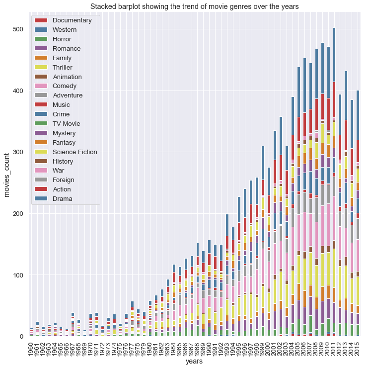

```python
# Plot a stacked barplot showing trend of movie genres over the years
ax = genre_count_per_year.plot.bar(stacked=True);
ax.set(xlabel='years', ylabel='movies_count', title = 'Stacked barplot showing the trend of movie genres over the years')
pt.show()
```

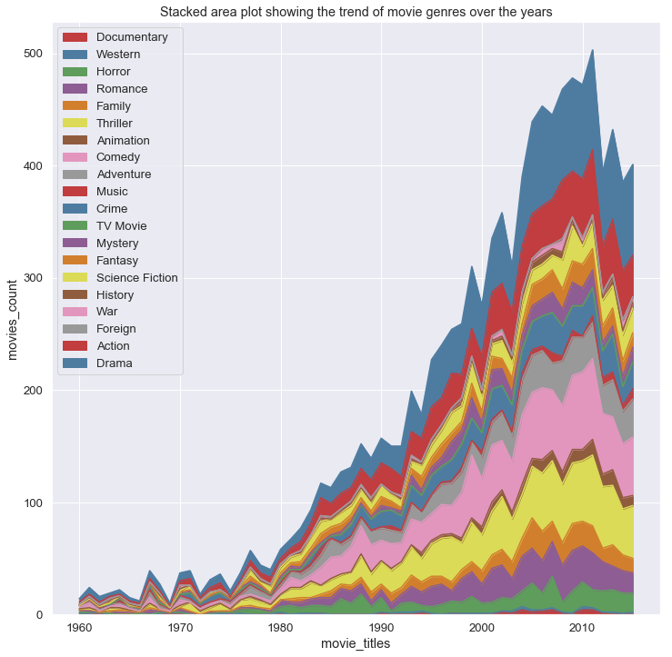

```python
# Plot a stacked area plot showing the trend of movie genres over the years
ax = genre_count_per_year.plot.area(stacked=True);
ax.set(xlabel='movie_titles', ylabel='movies_count', title = 'Stacked area plot showing the trend of movie genres over the years')
pt.show()
```

#### How many movies based on their genres were produced?

```python
# Calculate the sum of movies w.r.t. genres and sort in descending order
temp = genre_count_per_year.apply(sum)
temp = temp.sort_values(ascending= False)
temp
```

```
Drama              1754
Comedy             1358
Thriller           1203
Action             1085
Adventure           749
Romance             667
Crime               651
Science Fiction     519
Horror              463
Family              425
Fantasy             396
Mystery             344
Animation           201
Music               134
History             129
War                 119
Western              52
Documentary          31
Foreign              13
TV Movie              1
dtype: int64
```

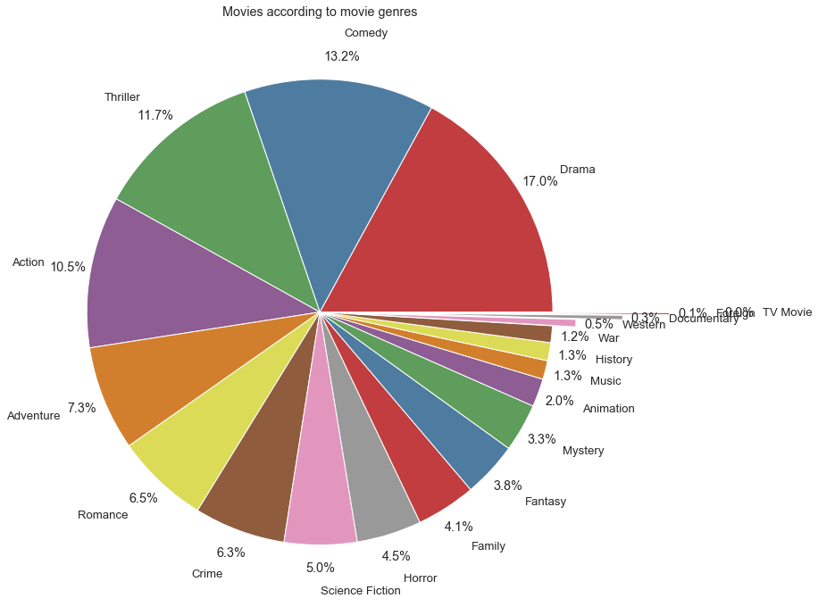

```python
# Plot a pie chart showing movie genres distribution
explode = (0, 0, 0, 0, 0, 0, 0, 0, 0, 0, 0, 0, 0, 0, 0, 0, 0.1, 0.3, 0.5, 0.7)

pt.pie(temp, labels=temp.index, explode = explode, autopct='%1.1f%%', pctdistance=1.1, labeldistance=1.2)
pt.title('Movies according to movie genres')

pt.show()
```

```python
# Set the size of the plot and font size
sns.set(rc={'figure.figsize':(12,9)}, font_scale=1.4)
```

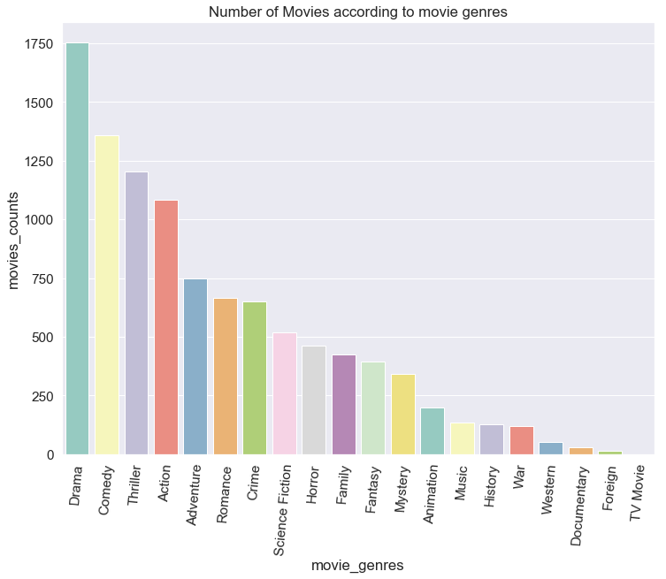

```python
# Plot a bar plot showing movie genres distribution
ax = sns.barplot(temp.index, temp, palette="Set3")

#rotate x-axis labels
for item in ax.get_xticklabels():
    item.set_rotation(85)

ax.set(xlabel='movie_genres', ylabel='movies_counts', title = 'Number of Movies according to movie genres')
pt.show()
```

### Research Question 2: Top movies based on features

#### Top movies based on their adjusted revenue

```python
# Fetch different columns needed for futher analysis
movies_and_revenue = df[["original_title", "revenue_adj"]]
movies_and_budget = df[['original_title','budget_adj']]
movies_and_popularity = df[['original_title','popularity']]
```

```python
# Set the size of the plot and font size
sns.set(rc={'figure.figsize':(12,9)}, font_scale=1.4)
```

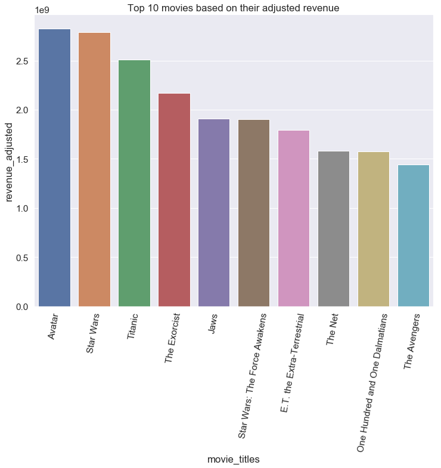

```python
# Plot a barplot showing top 10 movies based on revenue_adj
ax = sns.barplot(movies_and_revenue.sort_values(by = "revenue_adj", ascending=False).head(10).original_title, movies_and_revenue.sort_values(by = "revenue_adj", ascending=False).head(10).revenue_adj)

#rotate x-axis labels
for item in ax.get_xticklabels():
    item.set_rotation(80)

ax.set(xlabel='movie_titles', ylabel='revenue_adjusted', title = 'Top 10 movies based on their adjusted revenue')
pt.show()
```

> From the visualization above, it can be seen that the top 5 movies from the given dataset based on their adjusted revenues are; Avatar, Star Wars, Titanic, The Exorcist and Jaws.

#### Top Movies based on their budget

```python
# Set the size of the plot and font size
sns.set(rc={'figure.figsize':(12,9)}, font_scale=1.4)
```

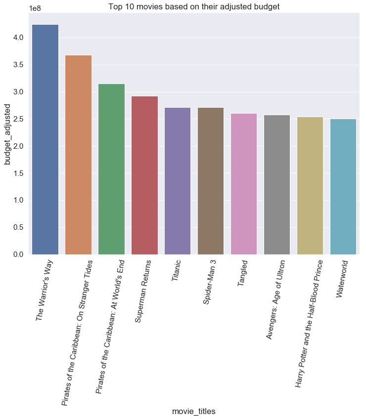

```python
# Plot a barplot showing top 10 movies based on budget_adj
ax = sns.barplot(movies_and_budget.sort_values(by="budget_adj", ascending=False).head(10).original_title, movies_and_budget.sort_values(by="budget_adj", ascending=False).head(10).budget_adj)

#rotate x-axis labels
for item in ax.get_xticklabels():
    item.set_rotation(80)

ax.set(xlabel='movie_titles', ylabel='budget_adjusted', title = 'Top 10 movies based on their adjusted budget')
pt.show()
```

> From the visualization above, it can be seen that the top 5 movies from the given dataset based on their adjusted budgets are; The Warrior's Way, Pirates of the Caribbean: On Stranger Tides, Pirates of the Caribbean: At World's Ends, Superman Returns, Titanic.

#### Top Movies based on their popularity

```python
# Set the size of the plot and font size
sns.set(rc={'figure.figsize':(12,9)}, font_scale=1.4)
```

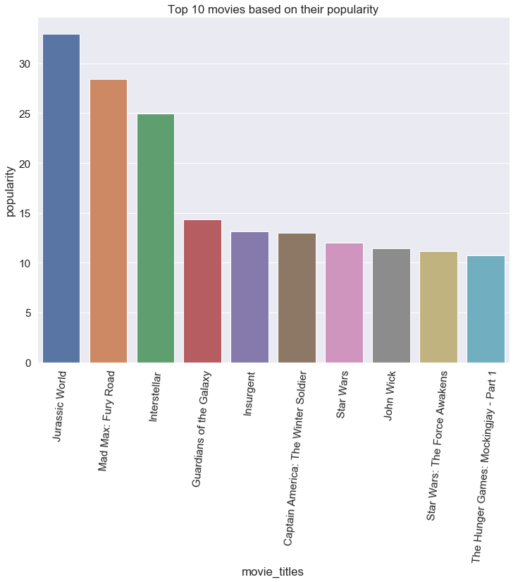

```python
# Plot a barplot showing top 10 movies based on their popularity
ax = sns.barplot(movies_and_popularity.sort_values(by="popularity", ascending=False).head(10).original_title, movies_and_popularity.sort_values(by="popularity", ascending=False).head(10).popularity)

#rotate x-axis labels
for item in ax.get_xticklabels():
    item.set_rotation(85)

ax.set(xlabel='movie_titles', ylabel='popularity', title = 'Top 10 movies based on their popularity')
pt.show()
```

### Research Question 3: Ananlysis of various factors on basis of revenues

#### Have revenues increased over time?

```python
df_with_decades = df.copy()

# Create a column for all the decades
bin_edges = [1959, 1970, 1980, 1990, 2000, 2010, 2015]
bin_names = ['Sixties', 'Seventies', 'Eighties', 'Nineties', 'Two_thousands', 'Two_thousand_tens']
df_with_decades['decades'] = pd.cut(df_with_decades['release_year'], bin_edges, labels=bin_names)
df_with_decades.head()
```

|  | id | popularity | budget(in_USD) | revenue(in_USD) | original_title | cast | director | tagline | runtime | genres | release_date | release_year | budget_adj | revenue_adj | decades |
| --- | --- | --- | --- | --- | --- | --- | --- | --- | --- | --- | --- | --- | --- | --- | --- |
| 0 | 135397 | 32.985763 | 150000000 | 1513528810 | Jurassic World | Chris Pratt\|Bryce Dallas Howard\|Irrfan Khan\|Vi... | Colin Trevorrow | The park is open. | 124 | Action\|Adventure\|Science Fiction\|Thriller | 2015-06-09 | 2015 | 1.379999e+08 | 1.392446e+09 | Two_thousand_tens |
| 1 | 76341 | 28.419936 | 150000000 | 378436354 | Mad Max: Fury Road | Tom Hardy\|Charlize Theron\|Hugh Keays-Byrne\|Nic... | George Miller | What a Lovely Day. | 120 | Action\|Adventure\|Science Fiction\|Thriller | 2015-05-13 | 2015 | 1.379999e+08 | 3.481613e+08 | Two_thousand_tens |
| 2 | 262500 | 13.112507 | 110000000 | 295238201 | Insurgent | Shailene Woodley\|Theo James\|Kate Winslet\|Ansel... | Robert Schwentke | One Choice Can Destroy You | 119 | Adventure\|Science Fiction\|Thriller | 2015-03-18 | 2015 | 1.012000e+08 | 2.716190e+08 | Two_thousand_tens |
| 3 | 140607 | 11.173104 | 200000000 | 2068178225 | Star Wars: The Force Awakens | Harrison Ford\|Mark Hamill\|Carrie Fisher\|Adam D... | J.J. Abrams | Every generation has a story. | 136 | Action\|Adventure\|Science Fiction\|Fantasy | 2015-12-15 | 2015 | 1.839999e+08 | 1.902723e+09 | Two_thousand_tens |
| 4 | 168259 | 9.335014 | 190000000 | 1506249360 | Furious 7 | Vin Diesel\|Paul Walker\|Jason Statham\|Michelle ... | James Wan | Vengeance Hits Home | 137 | Action\|Crime\|Thriller | 2015-04-01 | 2015 | 1.747999e+08 | 1.385749e+09 | Two_thousand_tens |

```python
# Calculate average revenue over the years and decades
rev = df_with_decades.groupby('release_year')['revenue(in_USD)'].mean()
print(df_with_decades.groupby('decades')['revenue(in_USD)'].mean())
```

```
decades
Sixties              4.213109e+07
Seventies            6.789086e+07
Eighties             6.563515e+07
Nineties             9.905034e+07
Two_thousands        1.121872e+08
Two_thousand_tens    1.419081e+08
Name: revenue(in_USD), dtype: float64
```

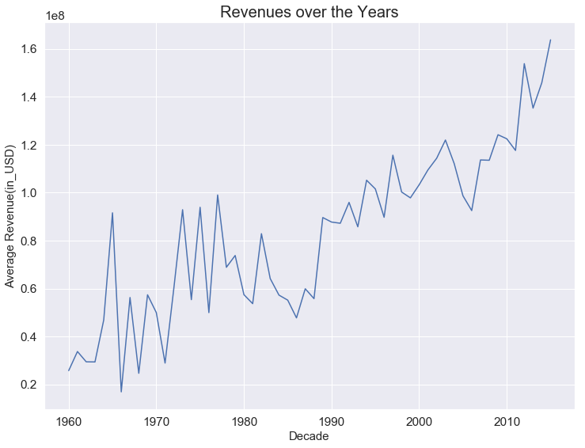

```python
# Plot a line chart for revenues over the years
pt.plot(rev)
pt.title('Revenues over the Years', size=20);
pt.xlabel('Decade', size=15)
pt.ylabel('Average Revenue(in_USD)', size=15);
```

```python
# Calculate the average revenue_adj over the years and decades
revenue_adj = df_with_decades.groupby('release_year')['revenue_adj'].mean()
print(df_with_decades.groupby('decades')['revenue_adj'].mean())
```

```
decades
Sixties              2.785353e+08
Seventies            2.567380e+08
Eighties             1.277342e+08
Nineties             1.380226e+08
Two_thousands        1.227232e+08
Two_thousand_tens    1.332167e+08
Name: revenue_adj, dtype: float64
```

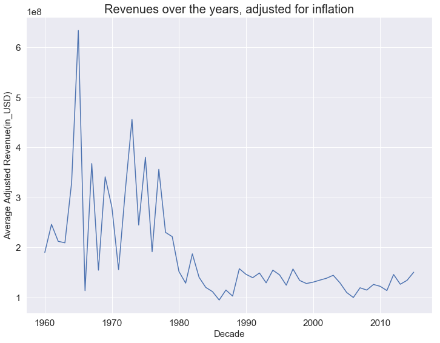

```python
# Plot a line chart for adjusted revenues over the years
pt.plot(revenue_adj)
pt.title('Revenues over the years, adjusted for inflation', size=20);
pt.xlabel('Decade', size=15)
pt.ylabel('Average Adjusted Revenue(in_USD)', size=15);
```

#### Do higher revenue films make more profits?

```python
# Add a profit column
# profit = revenue(in_USD) - budget(in_USD)
df_with_decades['profit(in_USD)'] = df_with_decades['revenue(in_USD)'] - df_with_decades['budget(in_USD)']
df_with_decades.head()
```

|  | id | popularity | budget(in_USD) | revenue(in_USD) | original_title | cast | director | tagline | runtime | genres | release_date | release_year | budget_adj | revenue_adj | decades | profit(in_USD) |
| --- | --- | --- | --- | --- | --- | --- | --- | --- | --- | --- | --- | --- | --- | --- | --- | --- |
| 0 | 135397 | 32.985763 | 150000000 | 1513528810 | Jurassic World | Chris Pratt\|Bryce Dallas Howard\|Irrfan Khan\|Vi... | Colin Trevorrow | The park is open. | 124 | Action\|Adventure\|Science Fiction\|Thriller | 2015-06-09 | 2015 | 1.379999e+08 | 1.392446e+09 | Two_thousand_tens | 1363528810 |
| 1 | 76341 | 28.419936 | 150000000 | 378436354 | Mad Max: Fury Road | Tom Hardy\|Charlize Theron\|Hugh Keays-Byrne\|Nic... | George Miller | What a Lovely Day. | 120 | Action\|Adventure\|Science Fiction\|Thriller | 2015-05-13 | 2015 | 1.379999e+08 | 3.481613e+08 | Two_thousand_tens | 228436354 |
| 2 | 262500 | 13.112507 | 110000000 | 295238201 | Insurgent | Shailene Woodley\|Theo James\|Kate Winslet\|Ansel... | Robert Schwentke | One Choice Can Destroy You | 119 | Adventure\|Science Fiction\|Thriller | 2015-03-18 | 2015 | 1.012000e+08 | 2.716190e+08 | Two_thousand_tens | 185238201 |
| 3 | 140607 | 11.173104 | 200000000 | 2068178225 | Star Wars: The Force Awakens | Harrison Ford\|Mark Hamill\|Carrie Fisher\|Adam D... | J.J. Abrams | Every generation has a story. | 136 | Action\|Adventure\|Science Fiction\|Fantasy | 2015-12-15 | 2015 | 1.839999e+08 | 1.902723e+09 | Two_thousand_tens | 1868178225 |
| 4 | 168259 | 9.335014 | 190000000 | 1506249360 | Furious 7 | Vin Diesel\|Paul Walker\|Jason Statham\|Michelle ... | James Wan | Vengeance Hits Home | 137 | Action\|Crime\|Thriller | 2015-04-01 | 2015 | 1.747999e+08 | 1.385749e+09 | Two_thousand_tens | 1316249360 |

```python
# Check if there are rows with 0 or negative values in profit column
df_with_decades[df_with_decades["profit(in_USD)"] <= 0].shape
```

```
(1073, 16)
```

```python
# Convert all negative values in profit column to 0
df_with_decades.loc[df_with_decades['profit(in_USD)'] < 0, 'profit(in_USD)'] = 0
```

```python
# Calculate the profitability ratio
# profitability_ratio = (profit/revenue) x 100
# Adjust for non-zero division by adding .0001 to the denominator, revenue
df_with_decades['profitability_ratio'] = (df_with_decades['profit(in_USD)'] / (df_with_decades['revenue(in_USD)'] + .0001)) * 100

# Convert profitability_ratio column from float to integer
df_with_decades['profitability_ratio'] = df_with_decades['profitability_ratio'].astype(int)
df_with_decades.head()
```

|  | id | popularity | budget(in_USD) | revenue(in_USD) | original_title | cast | director | tagline | runtime | genres | release_date | release_year | budget_adj | revenue_adj | decades | profit(in_USD) | profitability_ratio |
| --- | --- | --- | --- | --- | --- | --- | --- | --- | --- | --- | --- | --- | --- | --- | --- | --- | --- |
| 0 | 135397 | 32.985763 | 150000000 | 1513528810 | Jurassic World | Chris Pratt\|Bryce Dallas Howard\|Irrfan Khan\|Vi... | Colin Trevorrow | The park is open. | 124 | Action\|Adventure\|Science Fiction\|Thriller | 2015-06-09 | 2015 | 1.379999e+08 | 1.392446e+09 | Two_thousand_tens | 1363528810 | 90 |
| 1 | 76341 | 28.419936 | 150000000 | 378436354 | Mad Max: Fury Road | Tom Hardy\|Charlize Theron\|Hugh Keays-Byrne\|Nic... | George Miller | What a Lovely Day. | 120 | Action\|Adventure\|Science Fiction\|Thriller | 2015-05-13 | 2015 | 1.379999e+08 | 3.481613e+08 | Two_thousand_tens | 228436354 | 60 |
| 2 | 262500 | 13.112507 | 110000000 | 295238201 | Insurgent | Shailene Woodley\|Theo James\|Kate Winslet\|Ansel... | Robert Schwentke | One Choice Can Destroy You | 119 | Adventure\|Science Fiction\|Thriller | 2015-03-18 | 2015 | 1.012000e+08 | 2.716190e+08 | Two_thousand_tens | 185238201 | 62 |
| 3 | 140607 | 11.173104 | 200000000 | 2068178225 | Star Wars: The Force Awakens | Harrison Ford\|Mark Hamill\|Carrie Fisher\|Adam D... | J.J. Abrams | Every generation has a story. | 136 | Action\|Adventure\|Science Fiction\|Fantasy | 2015-12-15 | 2015 | 1.839999e+08 | 1.902723e+09 | Two_thousand_tens | 1868178225 | 90 |
| 4 | 168259 | 9.335014 | 190000000 | 1506249360 | Furious 7 | Vin Diesel\|Paul Walker\|Jason Statham\|Michelle ... | James Wan | Vengeance Hits Home | 137 | Action\|Crime\|Thriller | 2015-04-01 | 2015 | 1.747999e+08 | 1.385749e+09 | Two_thousand_tens | 1316249360 | 87 |

```python
# Find the top 100 movies in terms of revenues
df_top_hundred = df_with_decades.sort_values(by=['revenue(in_USD)'], ascending=False).head(100)
df_top_hundred['original_title'].nunique()
```

```
100
```

```python
df_top_hundred.describe()
```

|  | id | popularity | budget(in_USD) | revenue(in_USD) | runtime | release_year | budget_adj | revenue_adj | profit(in_USD) | profitability_ratio |
| --- | --- | --- | --- | --- | --- | --- | --- | --- | --- | --- |
| count | 100.000000 | 100.000000 | 1.000000e+02 | 1.000000e+02 | 100.000000 | 100.000000 | 1.000000e+02 | 1.000000e+02 | 1.000000e+02 | 100.000000 |
| mean | 43314.780000 | 5.191795 | 1.542350e+08 | 8.979584e+08 | 130.070000 | 2007.970000 | 1.570108e+08 | 9.654023e+08 | 7.437234e+08 | 81.550000 |
| std | 55833.708222 | 4.467371 | 6.694002e+07 | 3.189943e+08 | 25.168625 | 6.817172 | 6.237636e+07 | 4.034864e+08 | 3.069387e+08 | 7.990367 |
| min | 11.000000 | 0.436803 | 1.050000e+07 | 6.118994e+08 | 88.000000 | 1977.000000 | 2.372625e+07 | 5.726906e+08 | 3.990268e+08 | 62.000000 |
| 25% | 673.750000 | 2.755044 | 1.122500e+08 | 7.097980e+08 | 110.250000 | 2004.750000 | 1.149844e+08 | 7.086393e+08 | 5.694419e+08 | 75.750000 |
| 50% | 12299.500000 | 4.264860 | 1.500000e+08 | 8.079637e+08 | 132.000000 | 2010.000000 | 1.565855e+08 | 8.776267e+08 | 6.604137e+08 | 81.000000 |
| 75% | 69080.750000 | 6.067551 | 2.000000e+08 | 9.590500e+08 | 144.250000 | 2013.000000 | 1.924616e+08 | 1.062875e+09 | 7.998445e+08 | 88.250000 |
| max | 211672.000000 | 32.985763 | 3.800000e+08 | 2.781506e+09 | 201.000000 | 2015.000000 | 3.683713e+08 | 2.827124e+09 | 2.544506e+09 | 98.000000 |

> The min revenue for the top 100 movies is 6.118994e+08. Now two filters will be created, one with the top 100 movies and below.

```python
# Create filters with movies with revenue greater than and less than 6.118994e+08
below_hundred = df_with_decades[df_with_decades["revenue(in_USD)"] < 6.118994e+08]
top_hundred = df_with_decades[df_with_decades["revenue(in_USD)"] >= 6.118994e+08]
```

```python
print(below_hundred['popularity'].mean())
print(top_hundred['popularity'].mean())
print(below_hundred['profit(in_USD)'].mean())
print(top_hundred['profit(in_USD)'].mean())
print(below_hundred['profitability_ratio'].mean())
print(top_hundred['profitability_ratio'].mean())
```

```
1.0860178554666662
5.191794520000002
56642628.3944
743723379.16
43.712
81.55
```

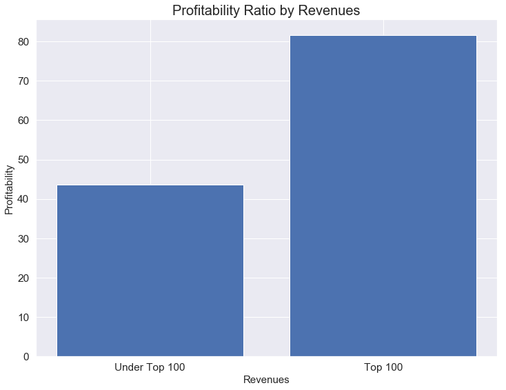

```python
# Plot a bar plot showing profitability ratio of the two sets of movies
locations = [1, 2]
heights = [below_hundred['profitability_ratio'].mean(), top_hundred['profitability_ratio'].mean()]
labels = ['Under Top 100', 'Top 100']
pt.bar(locations, heights, tick_label=labels)
pt.title('Profitability Ratio by Revenues', size=20)
pt.xlabel('Revenues', size=15)
pt.ylabel('Profitability', size=15)
```

```python
np.max(below_hundred['profitability_ratio'].mean())
```

```
43.712
```

```python
np.max(top_hundred['profitability_ratio'].mean())
```

```
81.55
```

> It can be seen that the movies that do better at the box office have a little less than double the profits as compared to those that make less. Movies under top 100 have profitability ratio of 44% and those in top 100 have profitabiity ratio of 82% which shows an increase of 38%.  
> So it can be concluded that top revenue movies have higher budgets and much higher profits.

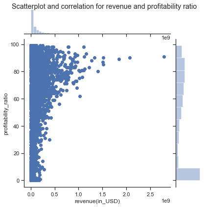

```python
# Check the correlation between revenue and profitability ratio through scatter plot
sns.set(rc={'figure.figsize':(20,20)}, font_scale=1, style="ticks")

f1 = sns.jointplot(x = "revenue(in_USD)", y = "profitability_ratio", kind = "scatter", color="b", data = df_with_decades)
f1.fig.suptitle('Scatterplot and correlation for revenue and profitability ratio')
pt.show()
```

> It is observed that revenue and profitability have a weak positive correlation.

## Conclusions

### Limitations

- All conclusions are limited to the underlying data set. As no advaned statistics were performed, the results can only be treated as indicators and are not generalizable.
- Vote count is different for different movies, so the popularity of the movies can't be concluded based on the average votes. This makes the vote_count and vote_average columns to be of no use.
- Dataset contains null and zero values in some features. These zero and null values hinder the analysis and have to be removed from the rows that correspond to these zero and null values.
- Many entries in the dataset have been removed due to missing data. If there were more observations in the analysis, the results could be different.
- Fewer movies were produced in the 20th century than movies produced in the 21st century. This could make the descritive statistics of movies in the past less robust than movies closer to the present.